# Factor Analysis of GCA

Derek Briggs

May 18, 2017

## Data

I’m going to break this data into two sets, one for EFA, one for CFA

```r
library(psych)
d<-read.csv("1516GCA.csv")
x<-seq(from=1, to=nrow(d), by=2)
y<-seq(from=2, to=nrow(d), by=2)
d1<-d[x,]
d2<-d[y,]
df<-as.data.frame(d)
```

## Item Descriptives and Reliability

Let’s have a look at item descriptives and alpha

```r
alpha(df,na.rm=T)
```

```
##
## Reliability analysis
## Call: alpha(x = df, na.rm = T)
##
##   raw_alpha std.alpha G6(smc) average_r S/N    ase mean   sd
##       0.84      0.84    0.84      0.17 5.1 0.0048 0.52 0.22
##
##  lower alpha upper     95% confidence boundaries
## 0.83 0.84 0.85
##
##  Reliability if an item is dropped:
##       raw_alpha std.alpha G6(smc) average_r S/N alpha se
## GCA1       0.83      0.83    0.83      0.17 4.8   0.0050
## GCA2       0.84      0.83    0.84      0.17 5.0   0.0048
## GCA3       0.84      0.84    0.84      0.18 5.1   0.0048
## GCA4       0.83      0.83    0.83      0.17 4.9   0.0050
## GCA5       0.83      0.83    0.83      0.17 4.9   0.0050
## GCA6       0.83      0.83    0.83      0.17 4.8   0.0050
## GCA7       0.83      0.83    0.83      0.17 4.8   0.0050
## GCA8       0.83      0.83    0.83      0.17 4.9   0.0049
## GCA9       0.84      0.83    0.84      0.17 5.1   0.0048
## GCA10      0.83      0.83    0.83      0.17 4.8   0.0051
## GCA11      0.83      0.83    0.83      0.17 4.8   0.0050
## GCA12      0.83      0.83    0.83      0.17 4.9   0.0050
## GCA13      0.83      0.83    0.83      0.17 4.9   0.0050
## GCA14      0.83      0.83    0.83      0.17 4.9   0.0049
## GCA15      0.84      0.83    0.83      0.17 5.0   0.0049
## GCA16      0.83      0.83    0.83      0.17 4.8   0.0050
## GCA17      0.83      0.83    0.83      0.17 4.9   0.0049
## GCA18      0.83      0.83    0.83      0.17 4.8   0.0050
## GCA19      0.84      0.84    0.84      0.18 5.3   0.0047
## GCA20      0.84      0.83    0.84      0.17 5.0   0.0048
## GCA21      0.83      0.83    0.83      0.17 4.8   0.0050
## GCA22      0.83      0.83    0.83      0.17 4.8   0.0050
## GCA23      0.83      0.83    0.83      0.17 4.8   0.0050
## GCA24      0.83      0.82    0.83      0.16 4.7   0.0051
## GCA25      0.83      0.83    0.83      0.17 4.8   0.0050
##
##  Item statistics
##          n raw.r std.r r.cor r.drop mean   sd
```

[output cut: 38 more lines]

```
## GCA11 0.56 0.44 0.12
## GCA12 0.54 0.46 0.12
## GCA13 0.29 0.71 0.12
## GCA14 0.45 0.55 0.12
## GCA15 0.60 0.40 0.12
## GCA16 0.49 0.51 0.12
## GCA17 0.52 0.48 0.12
## GCA18 0.53 0.47 0.12
## GCA19 0.18 0.82 0.12
## GCA20 0.69 0.31 0.12
## GCA21 0.51 0.49 0.12
## GCA22 0.61 0.39 0.12
## GCA23 0.61 0.39 0.12
## GCA24 0.62 0.38 0.13
## GCA25 0.50 0.50 0.13
```

One thing to notice here is that item 19 stands out as having by far the lowest correlations with total score based on all other GCA items.

## Dimensionality Analyses

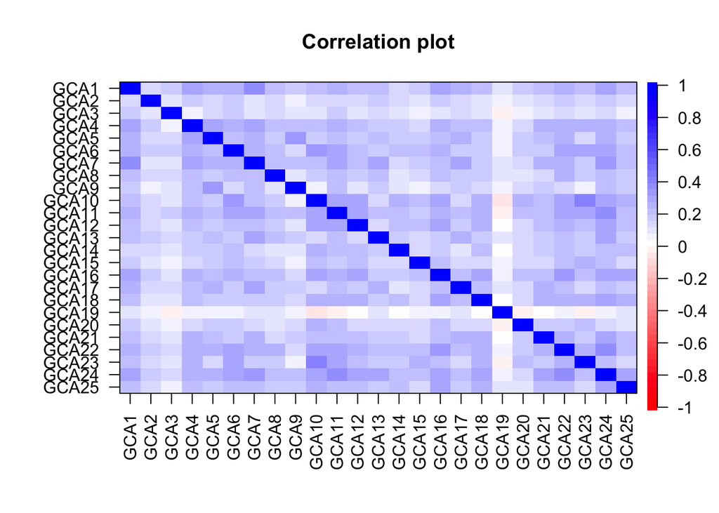

```r
cm<-cor(d1,use="complete.obs")
ev <- eigen(cm)
library(corrplot)
cor.plot(cm)
```

Let’s run a Parallel Analysis Scree Plot

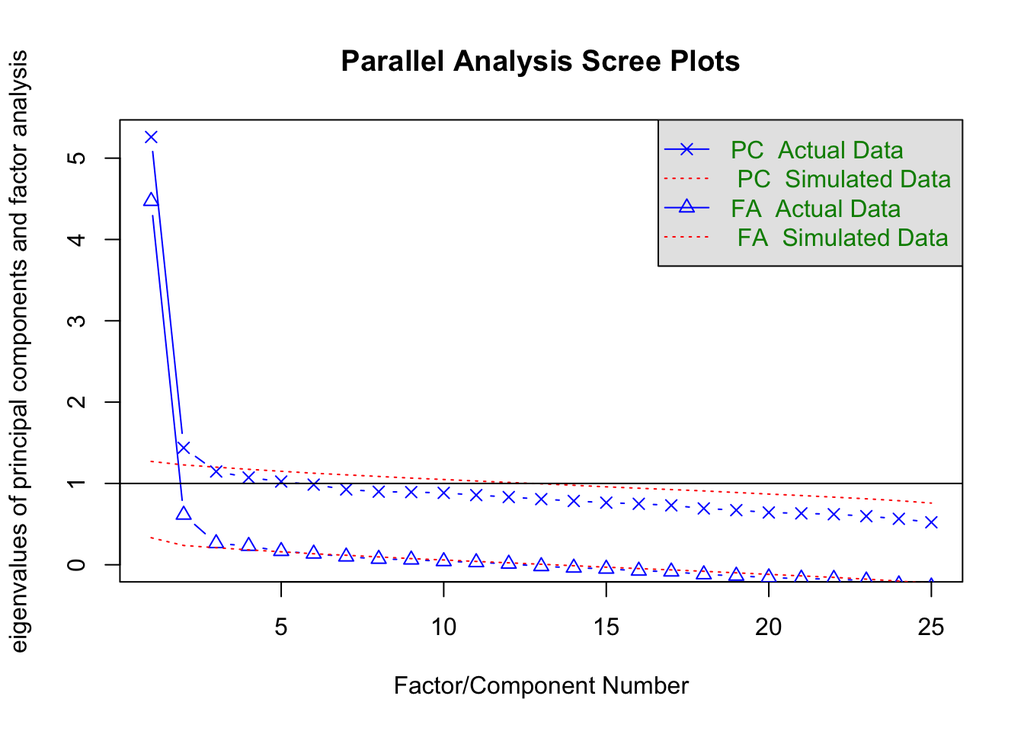

```
## Parallel analysis suggests that the number of factors =  6  and the number of components =  2
```

```r
fa.parallel(cm, n.obs = nrow(d1), fm="minres", fa="both",
            main = "Parallel Analysis Scree Plots",
            n.iter=100, error.bars=FALSE, SMC=FALSE,
            ylabel=NULL, show.legend=TRUE)
```

Starting with 2 Factors

```r
mod1<-fa(d1,nfactors=2,rotate="Promax",fm="pa",cor="tet")
print(mod1$loadings,cut=.3)
```

```
##
## Loadings:
##       PA2    PA1
## GCA1   0.542
## GCA2
## GCA3
## GCA4   0.466
## GCA5   0.662
## GCA6          0.550
## GCA7   0.682
## GCA8   0.351
## GCA9   0.661
## GCA10 -0.319  1.018
## GCA11         0.423
## GCA12         0.507
## GCA13  0.642
## GCA14         0.371
## GCA15         0.427
## GCA16         0.421
## GCA17  0.705
## GCA18         0.360
## GCA19  0.398
## GCA20         0.376
## GCA21  0.421
## GCA22         0.435
## GCA23         0.831
## GCA24  0.442  0.342
## GCA25
##
##                  PA2   PA1
## SS loadings    4.014 3.971
## Proportion Var 0.161 0.159
## Cumulative Var 0.161 0.319
```

```r
mod1$rms
```

```
## [1] 0.04332974
```

Not bad. We have a Heywood case due to item 10, and a cross-loading for items 24. But root mean residual is just .04. This solution explains about 32% of item covariance. Notice also that three items don’t have loadings > .3 on either factor (items 2, 3 and 25). Let’s try 3 factors.

```r
mod2<-fa(d1,nfactors=3,rotate="Promax",fm="pa",cor="tet")
print(mod2$loadings,cut=.3)
```

```
##
## Loadings:
##       PA1    PA2    PA3
## GCA1          0.444
## GCA2
## GCA3
## GCA4          0.496
## GCA5          0.799
## GCA6   0.600
## GCA7          0.552
## GCA8
## GCA9  -0.319  0.871
## GCA10  1.100        -0.338
## GCA11  0.476  0.415
## GCA12  0.567
## GCA13         0.428
## GCA14  0.409
## GCA15  0.474
## GCA16  0.476
## GCA17         0.569
## GCA18  0.408
## GCA19 -0.366         0.749
## GCA20  0.415        -0.327
## GCA21         0.386
## GCA22  0.490
## GCA23  0.892
## GCA24  0.400
## GCA25  0.331
##
##                  PA1   PA2   PA3
## SS loadings    4.877 3.330 1.275
## Proportion Var 0.195 0.133 0.051
## Cumulative Var 0.195 0.328 0.379
```

```r
mod2$rms
```

```
## [1] 0.03764688
```

The 3 factor solution explains a little more covariance, reduces root mean residual from .043 to .038. Still getting that Heywood case. Also notice that items 2, 3 and 8 don’t have loadings > .3. With three factors we get a lot more cross-loadings that show up–tricky to interpret. Item 19 now shows up as a problem. Lastly, let’s try 4 factors.

```r
mod3<-fa(d1,nfactors=4,rotate="Promax",fm="pa",cor="tet")
```

```r
print(mod3$loadings,cut=.3)
```

```
##
## Loadings:
##       PA2    PA1    PA4    PA3
## GCA1   0.447
## GCA2
## GCA3
## GCA4   0.498
## GCA5   0.777
## GCA6          0.554
## GCA7   0.550
## GCA8
## GCA9   0.810 -0.310
## GCA10         0.696  0.400
## GCA11  0.397  0.305
## GCA12                0.546
## GCA13  0.429
## GCA14                0.456
## GCA15         0.396
## GCA16                0.464
## GCA17  0.554
## GCA18                0.650
## GCA19                       0.679
## GCA20         0.358
## GCA21  0.328         0.378
## GCA22
## GCA23         0.898
## GCA24                0.506
## GCA25                0.671
##
##                  PA2   PA1   PA4   PA3
## SS loadings    3.063 2.472 2.272 0.975
## Proportion Var 0.123 0.099 0.091 0.039
## Cumulative Var 0.123 0.221 0.312 0.351
```

```r
mod3$rms
```

```
## [1] 0.03346377
```

OK, so this is interesting. With the 4 factor solution we no longer have the Heywood case, but now the cumulative proportion of variance explained is lower than it was in the 3 factor solution! Root mean residual is down to .033. But notice that only item 19 loads on the 4th factor. We also now lose item 22 on top of 2, 3 and 8. Here’s a visualization

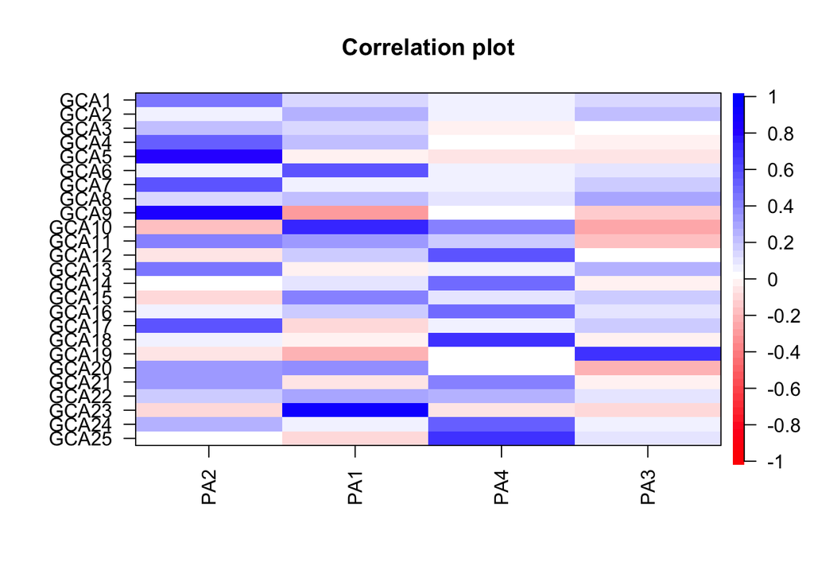

```r
cor.plot(mod3)
```

I’m going to try specifying a CFA model based on results from the two factor EFA. I’m gonna drop item 19 and not only keep strongest factor loading for each item.

## CFA

```r
library("lavaan")
fac3_mod <-
'factor1 =~ GCA1 + GCA4 + GCA7 + GCA8 + GCA9
+ GCA13 + GCA17 + GCA21 + GCA24
factor2 =~ GCA6 + GCA10 + GCA11 + GCA12 + GCA14
+ GCA15 + GCA16 + GCA18 + GCA20 + GCA22 + GCA23
+ GCA24'
fac3mod <- cfa(model = fac3_mod, data = d2, ordered = names(d2) ,estimator = "DWLS", se = "robust", test = "scaled.shifted", std.lv = TRUE)
summary(fac3mod,fit.measures = TRUE)
```

```
## lavaan (0.5-23.1097) converged normally after  23 iterations
##
##                                                   Used       Total
##   Number of observations                           997        1173
##
##   Estimator                                       DWLS      Robust
##   Minimum Function Test Statistic              139.748     195.046
##   Degrees of freedom                               168         168
##   P-value (Chi-square)                           0.945       0.075
##   Scaling correction factor                                  0.784
##   Shift parameter                                           16.892
##     for simple second-order correction (Mplus variant)
##
## Model test baseline model:
##
##   Minimum Function Test Statistic             8909.287    5909.108
##   Degrees of freedom                               190         190
##   P-value                                        0.000       0.000
##
## User model versus baseline model:
##
##   Comparative Fit Index (CFI)                    1.000       0.995
##   Tucker-Lewis Index (TLI)                       1.004       0.995
##
##   Robust Comparative Fit Index (CFI)                            NA
##   Robust Tucker-Lewis Index (TLI)                               NA
##
## Root Mean Square Error of Approximation:
##
##   RMSEA                                          0.000       0.013
##   90 Percent Confidence Interval          0.000  0.002       0.000  0.020
##   P-value RMSEA <= 0.05                          1.000       1.000
##
##   Robust RMSEA                                                  NA
##   90 Percent Confidence Interval                             0.000     NA
##
## Standardized Root Mean Square Residual:
##
##   SRMR                                           0.039       0.039
##
```

[output cut: 120 more lines]

```
##     GCA13             1.000
##     GCA17             1.000
##     GCA21             1.000
##     GCA24             1.000
##     GCA6              1.000
##     GCA10             1.000
##     GCA11             1.000
##     GCA12             1.000
##     GCA14             1.000
##     GCA15             1.000
##     GCA16             1.000
##     GCA18             1.000
##     GCA20             1.000
##     GCA22             1.000
##     GCA23             1.000
```

```r
mi <- modindices(fac3mod)
mi[mi$op == "=~",]
```

```
##         lhs op   rhs     mi mi.scaled    epc sepc.lv sepc.all sepc.nox
## 107 factor1 =~  GCA6  0.174     0.221  0.056   0.056    0.056    0.056
## 108 factor1 =~ GCA10  1.039     1.324 -0.143  -0.143   -0.143   -0.143
## 109 factor1 =~ GCA11  1.796     2.290  0.181   0.181    0.181    0.181
## 110 factor1 =~ GCA12  0.909     1.159 -0.127  -0.127   -0.127   -0.127
## 111 factor1 =~ GCA14  0.107     0.136  0.044   0.044    0.044    0.044
## 112 factor1 =~ GCA15  0.008     0.010  0.012   0.012    0.012    0.012
## 113 factor1 =~ GCA16  0.001     0.002  0.005   0.005    0.005    0.005
## 114 factor1 =~ GCA18  0.788     1.004 -0.119  -0.119   -0.119   -0.119
## 115 factor1 =~ GCA20  2.138     2.725 -0.204  -0.204   -0.204   -0.204
## 116 factor1 =~ GCA22 14.983    19.101  0.524   0.524    0.524    0.524
## 117 factor1 =~ GCA23  3.307     4.216 -0.250  -0.250   -0.250   -0.250
## 118 factor2 =~  GCA1  0.326     0.415 -0.083  -0.083   -0.083   -0.083
## 119 factor2 =~  GCA4  0.021     0.026 -0.020  -0.020   -0.020   -0.020
## 120 factor2 =~  GCA7  0.040     0.051 -0.030  -0.030   -0.030   -0.030
## 121 factor2 =~  GCA8  3.684     4.696  0.291   0.291    0.291    0.291
## 122 factor2 =~  GCA9  5.558     7.086 -0.311  -0.311   -0.311   -0.311
## 123 factor2 =~ GCA13  0.199     0.253  0.065   0.065    0.065    0.065
## 124 factor2 =~ GCA17  0.864     1.101 -0.125  -0.125   -0.125   -0.125
## 125 factor2 =~ GCA21  1.103     1.407  0.149   0.149    0.149    0.149
```

The fit of this model is pretty good. Of course, a problem is that I’ve played around with other possibilities that also fit equally well! Next step is to do a CFA based on mapping of items to intended learning objectives (1-8). Need at least two items per factor, so dropping GCA25 for now.

```r
fac7_mod <-
'factor1 =~ GCA3 + GCA6 + GCA10 + GCA14 + GCA16 + GCA18
factor2 =~ GCA1 + GCA8 + GCA17
factor3 =~ GCA2 + GCA7 + GCA20 + GCA22 + GCA23
factor4 =~ GCA13 + GCA24
factor5 =~ GCA5 + GCA9 +GCA19
factor6 =~ GCA4 + GCA11 + GCA12
factor7 =~ GCA15 + GCA21
'
fac7mod <- cfa(model = fac7_mod, data = d2, ordered = names(d2) ,estimator = "DWLS", se = "robust", test = "scaled.shifted", std.lv = TRUE)
summary(fac7mod,fit.measures = TRUE)
```

```
## lavaan (0.5-23.1097) converged normally after  52 iterations
##
##                                                   Used       Total
##   Number of observations                           997        1173
##
##   Estimator                                       DWLS      Robust
##   Minimum Function Test Statistic              281.843     366.437
##   Degrees of freedom                               231         231
##   P-value (Chi-square)                           0.012       0.000
##   Scaling correction factor                                  0.841
##   Shift parameter                                           31.480
##     for simple second-order correction (Mplus variant)
##
## Model test baseline model:
##
##   Minimum Function Test Statistic            10887.538    6969.583
##   Degrees of freedom                               276         276
##   P-value                                        0.000       0.000
##
## User model versus baseline model:
##
##   Comparative Fit Index (CFI)                    0.995       0.980
##   Tucker-Lewis Index (TLI)                       0.994       0.976
##
##   Robust Comparative Fit Index (CFI)                            NA
##   Robust Tucker-Lewis Index (TLI)                               NA
##
## Root Mean Square Error of Approximation:
##
##   RMSEA                                          0.015       0.024
##   90 Percent Confidence Interval          0.007  0.021       0.019  0.029
##   P-value RMSEA <= 0.05                          1.000       1.000
##
##   Robust RMSEA                                                  NA
##   90 Percent Confidence Interval                                NA     NA
##
## Standardized Root Mean Square Residual:
##
##   SRMR                                           0.048       0.048
##
```

[output cut: 179 more lines]

```
##     GCA2              1.000
##     GCA7              1.000
##     GCA20             1.000
##     GCA22             1.000
##     GCA23             1.000
##     GCA13             1.000
##     GCA24             1.000
##     GCA5              1.000
##     GCA9              1.000
##     GCA19             1.000
##     GCA4              1.000
##     GCA11             1.000
##     GCA12             1.000
##     GCA15             1.000
##     GCA21             1.000
```

```r
inspect(fac7mod,"cov.lv")
```

```
##         factr1 factr2 factr3 factr4 factr5 factr6 factr7
## factor1 1.000
## factor2 0.827  1.000
## factor3 0.985  0.952  1.000
## factor4 0.890  0.936  0.893  1.000
## factor5 0.679  0.850  0.765  0.761  1.000
## factor6 0.951  0.921  0.954  0.870  0.798  1.000
## factor7 0.936  0.904  0.959  0.929  0.866  0.972  1.000
```